# User_analysis

袁青野

# 本报告对2018-04-23用户至2018-05-06这两周的行为进行了分析

#### 包括反映用户数目的UV,反映用户活跃度的：人均PV,用户活跃时长,以及反映用户黏度的次日留存，报告还包含了路径深度的分析，转化部分的内容,并采用多种方式作图

#### 本次报告用R语言自动化生成报告的框架搭建，今后将在此基础上不断改进优化

# 用户黏性

## 次日留存

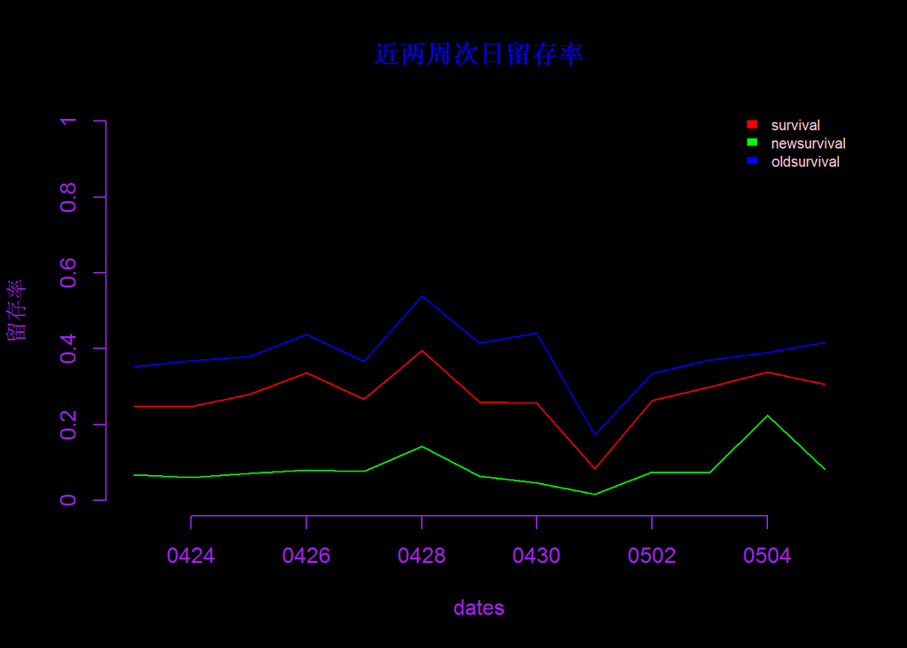

次日留存率，老用户在5月1日有个小低谷

# 用户活跃

## 近两周的日活跃度(UV)

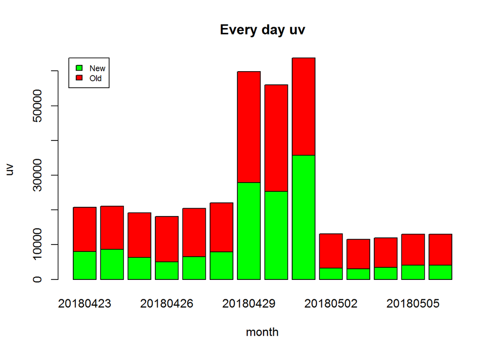

平均UV为26012,

最大UV为63775,

最大值发生在20180501

有1 天新用户在UV值上超过老用户

20180429, 20180430, 20180501 用户UV明显高于平均值  
20180426, 20180502, 20180503, 20180504, 20180505, 20180506 用户UV明显低于平均值  
整体uv值呈现先上升再下降的趋势

## 近两周人均PV

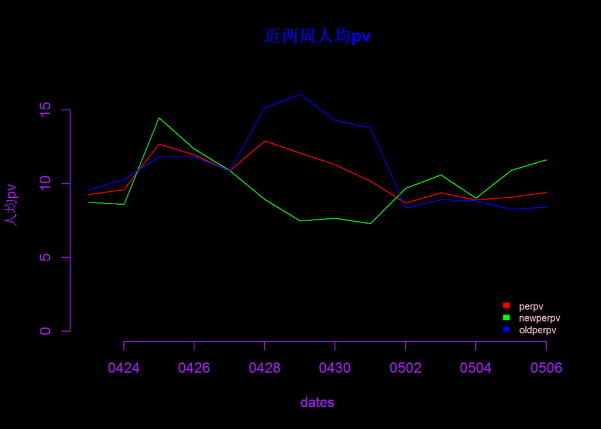

总体PV均值为10.4480551

总体PV最大值为12.8987726 最大值发生在 20180428

总体PV最小值为8.6895682 最小值发生在 20180502

新用户PV均值为9.8745709

新用户PV最大值为14.459032 最大值发生在 20180425

新用户PV最小值为7.304287 最小值发生在 20180501

老用户PV均值为11.1749089

老用户PV最大值为16.0654074 最大值发生在 20180429

老用户PV最小值为8.2745645 最小值发生在 20180505

有8 天新用户在人均PV值上超过老用户

20180424, 20180426, 20180428, 20180429, 20180430, 20180502, 20180505 新用户和老用户的趋势不一样

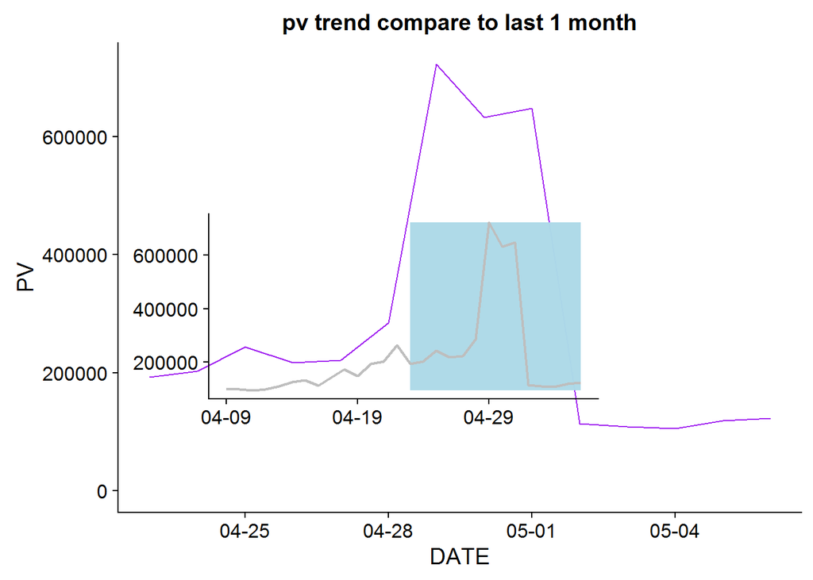

## 用户活跃时长

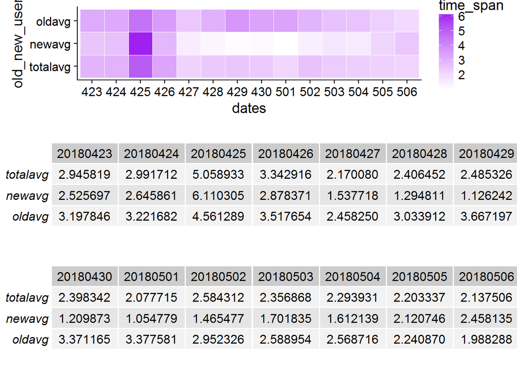

# 新用户注册渠道城市机型数量分析

## 新用户不同机型分布

|  | sym | model | 2018-04-23 | 2018-04-24 | 2018-04-25 | 2018-04-26 | 2018-04-27 | 2018-04-28 | 2018-04-29 | 2018-04-30 | 2018-05-01 | 2018-05-02 | 2018-05-03 | 2018-05-04 | 2018-05-05 | 2018-05-06 | sum | rank |
| --- | --- | --- | --- | --- | --- | --- | --- | --- | --- | --- | --- | --- | --- | --- | --- | --- | --- | --- |
| 1 | 1▲ | iPhone 5s | 66 | 52 | 107 | 143 | 594 | 499 | 1905 | 1127 | 2203 | 5 | 6 | 187 | 5 | 11 | 6910 | 1 |
| 2 | 5▲ | iPhone 5 | 49 | 22 | 76 | 138 | 568 | 472 | 1858 | 1088 | 2149 |  | 1 | 192 | 7 | 2 | 6622 | 2 |
| 3 | -2▼ | iPhone 6 | 150 | 141 | 138 | 229 | 431 | 436 | 1714 | 1083 | 1760 | 36 | 45 | 165 | 88 | 62 | 6478 | 3 |
| 4 | 4▲ | iPhone 5c | 28 |  | 50 | 81 | 539 | 385 | 1829 | 1123 | 2054 |  | 2 | 206 | 1 |  | 6298 | 4 |
| 5 | 0 | iPhone 6 Plus | 115 | 121 | 102 | 174 | 427 | 381 | 1204 | 756 | 1357 | 32 | 33 | 117 | 75 | 58 | 4952 | 5 |
| 6 | -3▼ | iPhone 6s | 151 | 165 | 118 | 121 | 421 | 393 | 1100 | 711 | 1150 | 39 | 43 | 194 | 91 | 86 | 4783 | 6 |
| 7 | -3▼ | iPhone 6s Plus | 136 | 124 | 106 | 95 | 441 | 374 | 1102 | 748 | 1167 | 28 | 51 | 165 | 103 | 85 | 4725 | 7 |
| 8 | 8▲ | iPhone 4S | 25 |  | 34 | 61 | 281 | 198 | 871 | 486 | 852 |  |  | 88 | 2 |  | 2898 | 8 |
| 9 | 15▲ | OPPO R9m | 96 | 266 | 122 | 79 | 54 | 67 | 510 | 626 | 573 | 52 | 44 | 62 | 44 | 50 | 2645 | 9 |
| 10 | -4▼ | iPhone 7 Plus | 161 | 136 | 141 | 132 | 138 | 174 | 418 | 303 | 363 | 37 | 63 | 146 | 166 | 145 | 2523 | 10 |

[output cut: 90 more lines]

iphone手机排名前列，前十名绝大部分被iphone系列手机占据,OPPO R9m 排名第9,上升15位,OPPO R9s,排名第11,Redmi Note 3,排名第12,上升6位,MI 6,排名第14 大促期间流量高，平时流量低

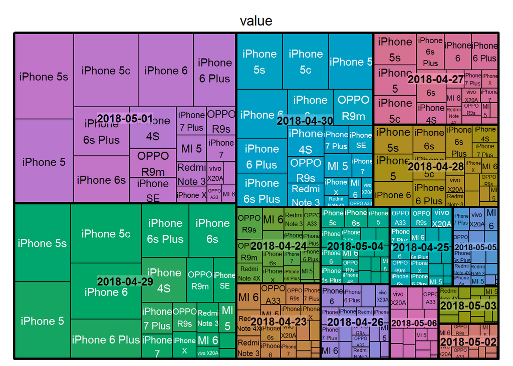

结构矩形树图，大矩形为日期，小矩形为具体机型，按从大到小的顺序，从上到下，从左到右排列

## 新用户不同城市分布

|  | sym | city | 2018-04-23 | 2018-04-24 | 2018-04-25 | 2018-04-26 | 2018-04-27 | 2018-04-28 | 2018-04-29 | 2018-04-30 | 2018-05-01 | 2018-05-02 | 2018-05-03 | 2018-05-04 | 2018-05-05 | 2018-05-06 | sum | rank |
| --- | --- | --- | --- | --- | --- | --- | --- | --- | --- | --- | --- | --- | --- | --- | --- | --- | --- | --- |
| 1 | 52▲ | 漯河 | 9 | 18 | 153 | 8 | 4 | 6 | 5708 | 7283 | 9883 | 11 | 7 | 4 | 7 | 2 | 23096 | 1 |
| 2 | -1▼ | 上海 | 779 | 899 | 702 | 828 | 1562 | 1244 | 1950 | 1862 | 3053 | 285 | 288 | 265 | 387 | 344 | 14061 | 2 |
| 3 | 18▲ | 徐州 | 96 | 108 | 62 | 40 | 44 | 31 | 2609 | 3524 | 3498 | 33 | 22 | 18 | 44 | 31 | 10116 | 3 |
| 4 | -2▼ | 北京 | 496 | 598 | 478 | 430 | 424 | 511 | 1364 | 891 | 1120 | 239 | 179 | 229 | 340 | 321 | 7280 | 4 |
| 5 | -1▼ | 苏州 | 368 | 369 | 236 | 199 | 185 | 1299 | 1363 | 1155 | 1020 | 92 | 80 | 67 | 161 | 125 | 6558 | 5 |
| 6 | -3▼ | 南京 | 482 | 436 | 319 | 336 | 275 | 425 | 1582 | 838 | 986 | 116 | 123 | 126 | 147 | 214 | 6258 | 6 |
| 7 | -1▼ | 石家庄 | 275 | 262 | 214 | 206 | 440 | 324 | 386 | 345 | 377 | 83 | 56 | 72 | 127 | 97 | 3137 | 7 |
| 8 | 4▲ | 武汉 | 260 | 225 | 162 | 128 | 231 | 184 | 519 | 615 | 554 | 83 | 57 | 66 | 89 | 83 | 3167 | 8 |
| 9 | -2▼ | 合肥 | 145 | 160 | 103 | 89 | 64 | 121 | 180 | 451 | 1519 | 52 | 62 | 57 | 87 | 79 | 3082 | 9 |
| 10 | -5▼ | 重庆 | 416 | 491 | 324 | 278 | 227 | 193 | 208 | 204 | 217 | 105 | 88 | 119 | 135 | 156 | 3026 | 10 |

[output cut: 91 more lines]

漯河，上海，徐州，北京，苏州占据前五名

**漯河，徐州，台州，常州，温州，湖州，南昌，丽水，金华，衢州，赣州，泉州，淮北名次上升较多**  
**宁波，郑州，无锡，天津，沈阳，成都，深圳等城市名次下降较多**

这两周，流量整体较大，漯河等城市出现非常明显的暴增流量

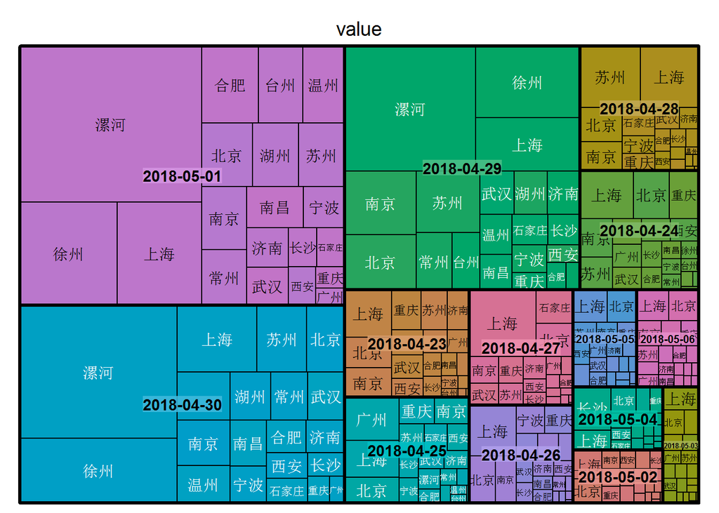

结构矩形树图，大矩形为日期，小矩形为具体城市，按从大到小的顺序，从上到下，从左到右排列

## 新用户不同渠道分布

|  | channels | 2018-04-23 | 2018-04-24 | 2018-04-25 | 2018-04-26 | 2018-04-27 | 2018-04-28 | 2018-04-29 | 2018-04-30 | 2018-05-01 | 2018-05-02 | 2018-05-03 | 2018-05-04 | 2018-05-05 | 2018-05-06 | sum |
| --- | --- | --- | --- | --- | --- | --- | --- | --- | --- | --- | --- | --- | --- | --- | --- | --- |
| 1 | 二维码-Android | 984 | 778 | 408 | 828 | 1162 | 1404 | 8508 | 11715 | 16342 | 217 | 219 | 23 | 44 | 22 | 42654 |
| 2 | 二维码-IOS | 341 | 289 | 323 | 494 | 1264 | 2507 | 11734 | 6994 | 13461 | 38 | 16 | 550 | 64 | 30 | 38105 |
| 3 | 小米1 | 2047 | 1670 | 705 | 772 | 708 | 818 | 1200 | 963 | 906 | 798 | 767 | 736 | 843 | 824 | 13757 |
| 4 | 百度手助1 | 1280 | 1090 | 965 | 467 | 246 | 433 | 603 | 569 | 876 | 815 | 719 | 696 | 1123 | 1113 | 10995 |
| 5 | oppo推广 | 790 | 2322 | 1137 | 493 | 424 | 478 | 450 | 469 | 416 | 376 | 366 | 523 | 528 | 575 | 9347 |
| 6 | 30015 | 140 | 164 | 214 | 145 | 394 | 684 | 2910 | 2178 | 1698 | 194 | 153 | 30 | 32 | 29 | 8965 |
| 7 | Appstore | 537 | 566 | 464 | 472 | 1206 | 493 | 905 | 709 | 624 | 161 | 232 | 382 | 455 | 435 | 7641 |
| 8 | vivo1 | 538 | 760 | 734 | 535 | 398 | 489 | 472 | 482 | 471 | 385 | 300 | 210 | 655 | 762 | 7191 |
| 9 | 华为1 | 424 | 399 | 373 | 288 | 322 | 318 | 599 | 487 | 481 | 205 | 221 | 189 | 262 | 254 | 4822 |
| 10 | 360手助1 | 465 | 282 | 304 | 241 | 130 | 291 | 360 | 369 | 293 | 53 | 30 | 33 | 16 | 28 | 2895 |

[output cut: 39 more lines]

二维码-ANDROID第一,二维码-IOS第二，小米排第三，然后是百度助手,oppo推广,30015，Appstore

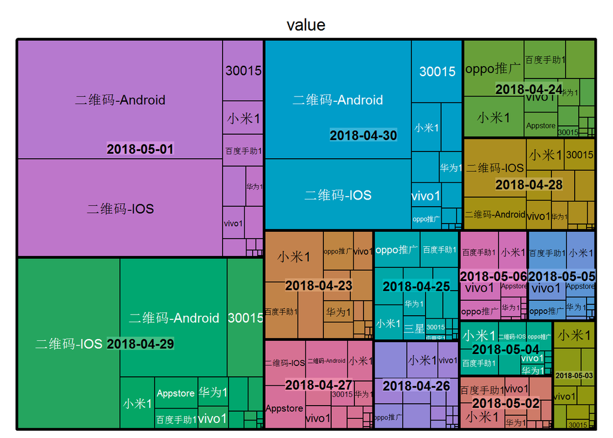

结构矩形树图，大矩形为日期，小矩形为具体渠道，按从大到小的顺序，从上到下，从左到右排列

# 产出（通过订单转化，领券等衡量）

## 每日订单数

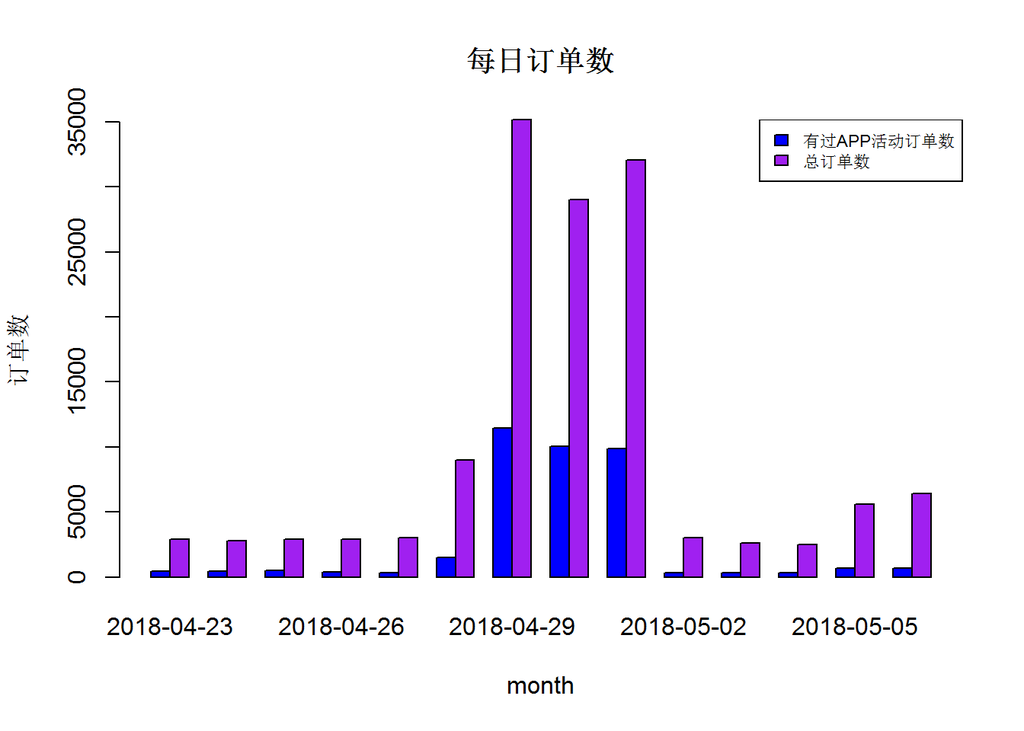

在APP上有过活动的人生成的订单占比较少，订单高峰发生在4月29日到5月1日，峰值有30000单左右，平时订单很少，基本在5000单以下，周一到周日有上升趋势

## 家装预约

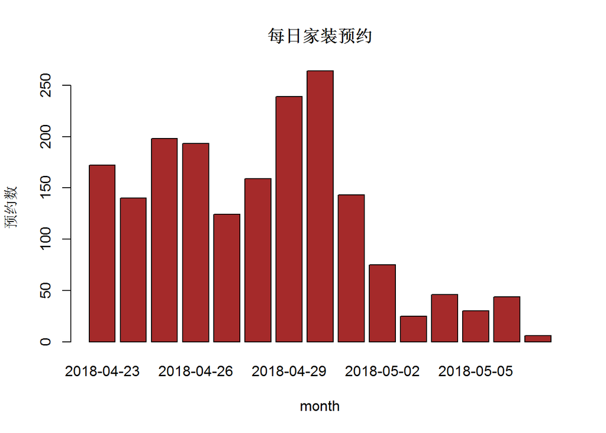

**整体预约出现逐渐下降趋势**，5月1日前预约较多，预约高达150-250，但之后预约数降到50以下，  
相比上月 *4月4日预约数最多，最高预约数100出头，平时预约数在50以下* 有了明显的改善

## 领券情况

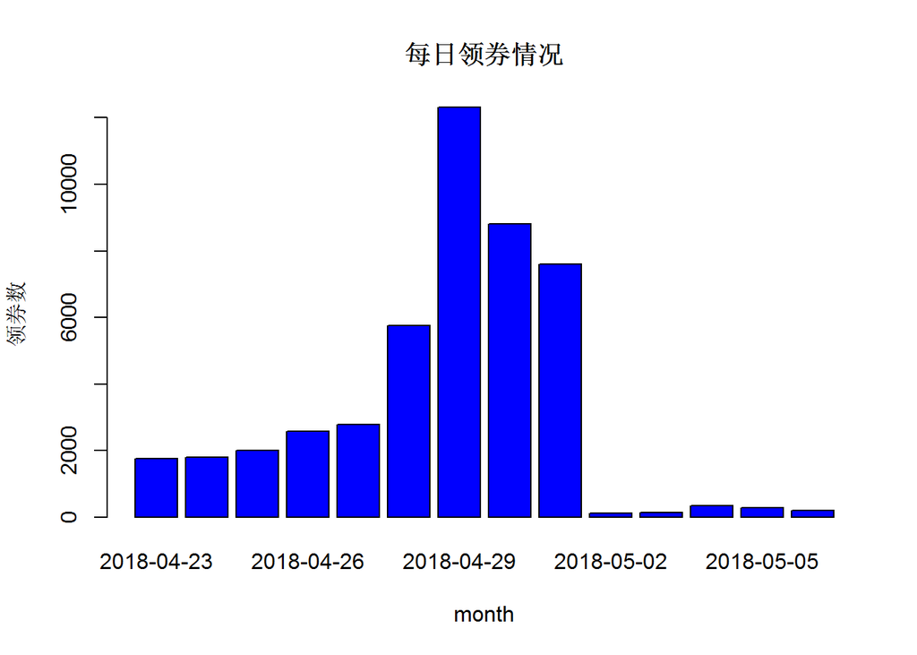